# Comparación de Pacientes en Cirugía de Implantes Dentales: Colocación vs. Periimplantaria

Grupo Proyecto 3

2024-03-07

# INTRODUCCIÓN

Este análisis compara las **características de pacientes sometidos a cirugía de colocación de implantes en la unidad de Implantología Bucal** con aquellos tratados en la **Unidad de Mantenimiento de Implantes**. El **objetivo** es **identificar factores de riesgo para complicacione**s en implantes dentales, **mejorando** así la **atención clínica** y la selección de pacientes.

# CARGA Y LIMPIEZA DE DATOS

## Carga

```r
# Cargamos los datos
data = read.csv('combianted_Total.csv')

#Visualizamos los tipos de cirugia
unique(data$Tipo_De_Intervencion_Quirurgica)
```

```
## [1] "Cirugia Dentoalveolar"    "0"
## [3] "Implantologia Bucal"      "Cirugía Peri-implantaria"
```

En odontología, tenemos tres tipos principales de intervenciones quirúrgicas:

1. *Cirugía Dentoalveolar*: Tratamiento de enfermedades y afecciones dentales y de los tejidos circundantes.
2. *Implantología Bucal*: Colocación de implantes dentales para reemplazar dientes perdidos.
3. *Cirugía Peri-implantaria*: Tratamiento de afecciones alrededor de los implantes dentales.

Nos centraremos en las intervenciones de **Implantología Bucal** y **Cirugía Peri-implantaria** para este estudio.

## Creación de los 2 conjuntos

Para enfocarnos en las dos intervenciones más relevantes, procederemos a filtrar los datos para incluir únicamente los casos relacionados con **Implantología Bucal** y **Cirugía Peri-implantaria**.

```r
library(dplyr)
datos_Implantologia_Bucal <- data %>%
  filter(data$Tipo_De_Intervencion_Quirurgica == "Implantologia Bucal")

#head(datos_Implantologia_Bucal)

datos_Periimplantaria <- data %>%
  filter(data$Tipo_De_Intervencion_Quirurgica == "Cirugía Peri-implantaria")


datos_Implantologia_Bucal <- datos_Implantologia_Bucal[, 1:57]
datos_Periimplantaria <- datos_Periimplantaria[, 1:57]
#head(datos_Periimplantaria)
```

Primero, creamos un subconjunto llamado *‘datos_Implantologia_Bucal’*, que contiene únicamente las filas de *‘data’* donde la variable *‘Tipo_De_Intervencion_Quirurgica’* es igual a *‘Implantologia Bucal’*.

Luego, creamos otro subconjunto llamado *‘datos_Periimplantaria’*, que contiene las filas de *‘data’* donde la variable *‘Tipo_De_Intervencion_Quirurgica’* es igual a *‘Cirugía Peri-implantaria’*.

Finalmente, ambos subconjuntos se reducen a las primeras 57 columnas y se asignan a las variables *‘datos_Implantologia_Bucal’* y *‘datos_Periimplantaria’*, respectivamente.

## Limpieza

Por último, vamos a limpiar los datos y prerararlo para los análisis.

```r
library(dplyr)
datos_Implantologia_Bucal_p <- datos_Implantologia_Bucal %>%
  select_if(is.numeric)

datos_Periimplantaria_p <- datos_Periimplantaria %>%
  select_if(is.numeric)

# Asignar el ID del paciente como nombre de fila: IMPLANTOLOGIA
row.names(datos_Implantologia_Bucal_p) <- datos_Implantologia_Bucal_p$ID_Paciente

datos_Implantologia_Bucal_p <- datos_Implantologia_Bucal_p[, !colnames(datos_Implantologia_Bucal_p) %in% c("ID_Paciente","Cigarros.Diarios")]


# Asignar el ID del paciente como nombre de fila: Periimplantitis
row.names(datos_Periimplantaria_p) <- datos_Periimplantaria_p$ID_Paciente

datos_Periimplantaria_p <- datos_Periimplantaria_p[, !colnames(datos_Periimplantaria_p) %in% c("ID_Paciente", "Cigarros.Diarios")]
```

Primero, se seleccionan solo las columnas numéricas de cada conjunto de datos utilizando la función *‘select_if(is.numeric)’*, lo que resulta en los conjuntos de datos *‘datos_Implantologia_Bucal_p’* y *‘datos_Periimplantaria_p’*.

Luego, se asigna el ID del paciente como nombre de fila en cada conjunto de datos, utilizando la función *‘row.names’*. Esto se hace para facilitar el seguimiento de los pacientes en el análisis posterior.

El código prepara los datos para análisis posteriores al filtrar solo las columnas numéricas, asignar nombres de fila basados en el ID del paciente y eliminar columnas no deseadas.

# PCA

En este análisis de PCA, exploraremos las características de los pacientes sometidos a **Implantología Bucal** y **Cirugía Periimplantaria** en odontología. El PCA nos permitirá identificar patrones y relaciones entre las variables, proporcionando conociiento sobre las diferencias y similitudes entre ambas intervenciones quirúrgicas.

## Implantologia

```r
library(factoextra)
library(cluster)
library(gridExtra)
```

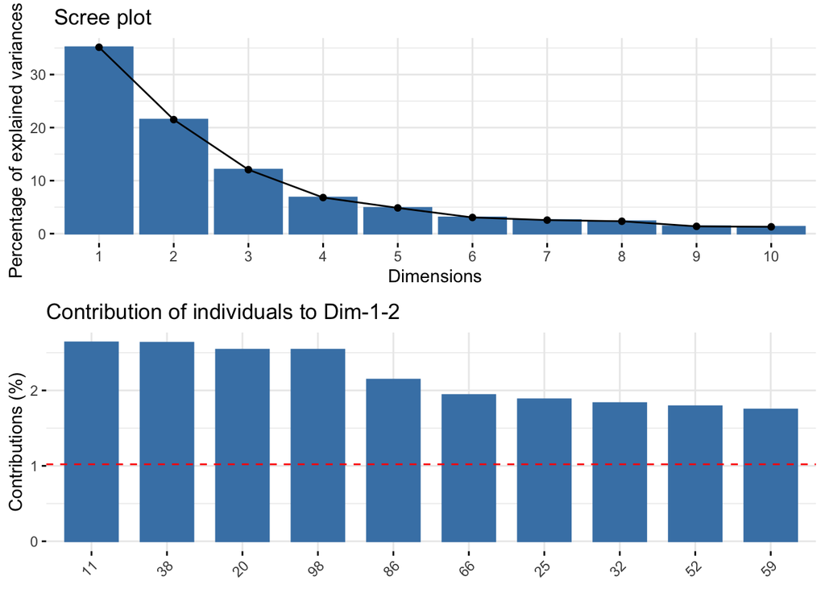

```r
# Realizar el análisis de componentes principales (PCA)
pca_result <- prcomp(datos_Implantologia_Bucal_p)

# Gráfico de la varianza explicada por cada componente principal
plot_eigenvalues <- fviz_eig(pca_result)

# Gráfico de las contribuciones de las variables a los ejes principales
plot_var_contrib <- fviz_contrib(pca_result, choice = "var", axes = 1:2, top = 10)

# Gráfico de las contribuciones de los individuos a los ejes principales
plot_ind_contrib <- fviz_contrib(pca_result, choice = "ind", axes = 1:2, top = 10)

# Organizar los gráficos en una cuadrícula
grid.arrange(plot_eigenvalues, plot_ind_contrib,
             ncol = 1)
```

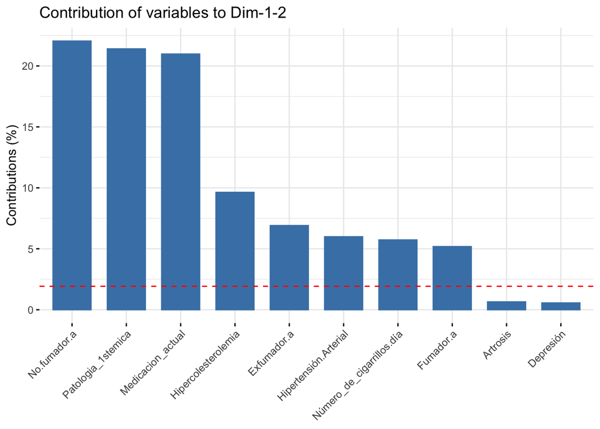

```r
plot_var_contrib
```

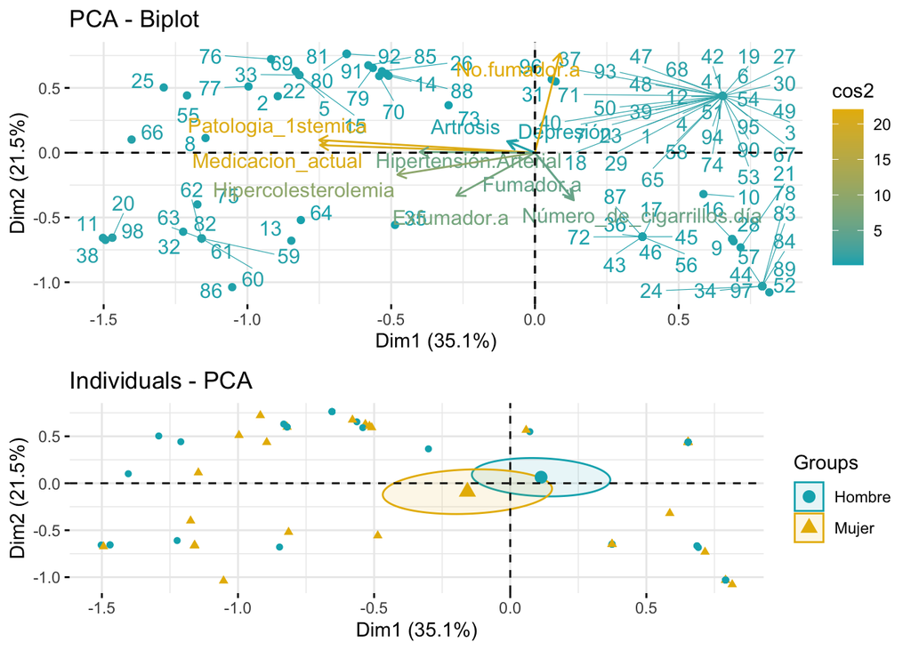

```r
# Biplot con las variables más importantes
plot_biplot <- fviz_pca_biplot(pca_result,
                               col.ind = "cos2",
                               select.var = list(contrib = 10),
                               col.var = "contrib",
                               repel = TRUE,
                               ggtheme = theme_minimal()) +
  theme(legend.position = "right") +
  scale_color_gradient(low = "#00AFBB", high = "#E7B800") +
  scale_shape_manual(values = c(1, 16))

# Gráfico de las contribuciones de las variables al PCA
plot_var_contrib_pca <- fviz_pca_var(pca_result,
                                     select.var = list(contrib = 10),
                                     col.var = "contrib",
                                     gradient.cols = c("#00AFBB", "#E7B800", "#FC4E07"),
                                     repel = TRUE)

# Gráfico de los individuos en el PCA con colores por género
plot_ind_pca_gender <- fviz_pca_ind(pca_result,
                                    label = "none",
                                    habillage = datos_Implantologia_Bucal$Genero,
                                    palette = c("#00AFBB", "#E7B800", "#FC4E07"),
                                    addEllipses = TRUE,
                                    ellipse.type = "confidence",
                                    repel = TRUE)

# Organizar los gráficos en una cuadrícula
grid.arrange(plot_biplot, plot_ind_pca_gender,
             ncol = 1, heights = c(5, 4))
```

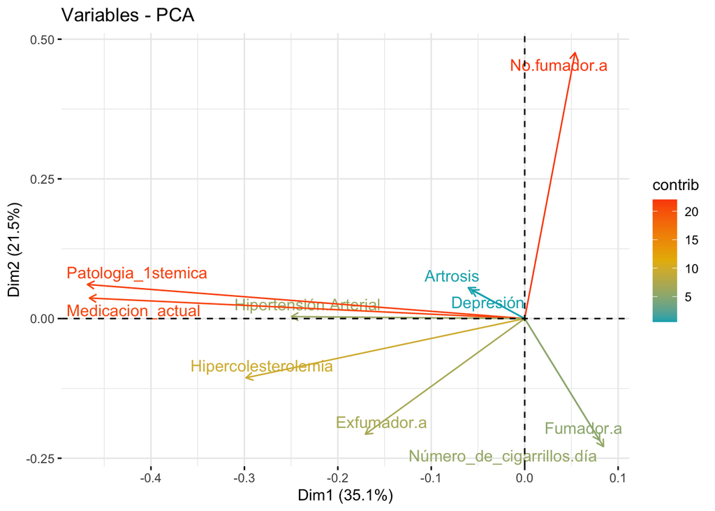

```r
plot_var_contrib_pca
```

## Periimplantitis

[figure not shown]

```r
# Realizar el análisis de componentes principales (PCA)
pca_result2 <- prcomp(datos_Periimplantaria_p)

# Gráfico de la varianza explicada por cada componente principal
plot_eigenvalues2 <- fviz_eig(pca_result2)

# Gráfico de las contribuciones de las variables a los ejes principales
plot_var_contrib2 <- fviz_contrib(pca_result2, choice = "var", axes = 1:2, top = 10)

# Gráfico de las contribuciones de los individuos a los ejes principales
plot_ind_contrib2 <- fviz_contrib(pca_result2, choice = "ind", axes = 1:2, top = 10)

# Organizar los gráficos en una cuadrícula
grid.arrange(plot_eigenvalues, plot_ind_contrib,
             ncol = 1)
```

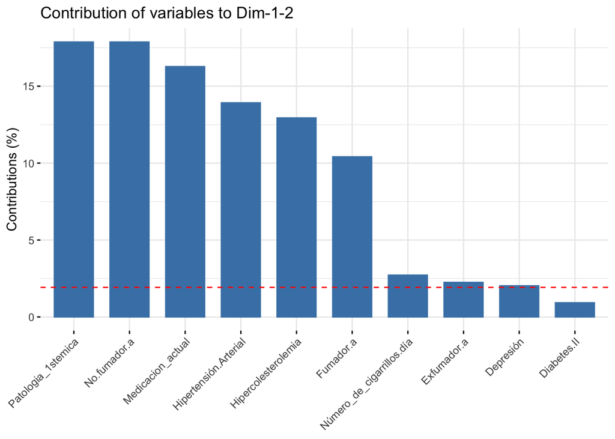

```r
plot_var_contrib2
```

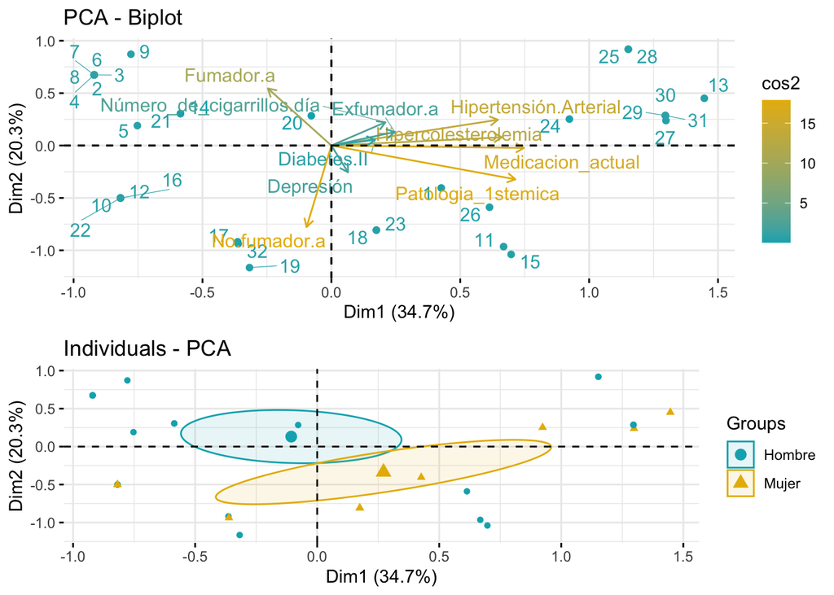

```r
# Biplot con las variables más importantes
plot_biplot2 <- fviz_pca_biplot(pca_result2,
                               col.ind = "cos2",
                               select.var = list(contrib = 10),
                               col.var = "contrib",
                               repel = TRUE,
                               ggtheme = theme_minimal()) +
  theme(legend.position = "right") +
  scale_color_gradient(low = "#00AFBB", high = "#E7B800") +
  scale_shape_manual(values = c(1, 16))

# Gráfico de las contribuciones de las variables al PCA
plot_var_contrib_pca2 <- fviz_pca_var(pca_result2,
                                     select.var = list(contrib = 10),
                                     col.var = "contrib",
                                     gradient.cols = c("#00AFBB", "#E7B800", "#FC4E07"),
                                     repel = TRUE)

# Gráfico de los individuos en el PCA con colores por género
plot_ind_pca_gender2 <- fviz_pca_ind(pca_result2,
                                    label = "none",
                                    habillage = datos_Periimplantaria$Genero,
                                    palette = c("#00AFBB", "#E7B800"),
                                    addEllipses = TRUE,
                                    ellipse.type = "confidence",
                                    repel = TRUE)

# Organizar los gráficos en una cuadrícula
grid.arrange(plot_biplot2, plot_ind_pca_gender2,
             ncol = 1, heights = c(5, 4))
```

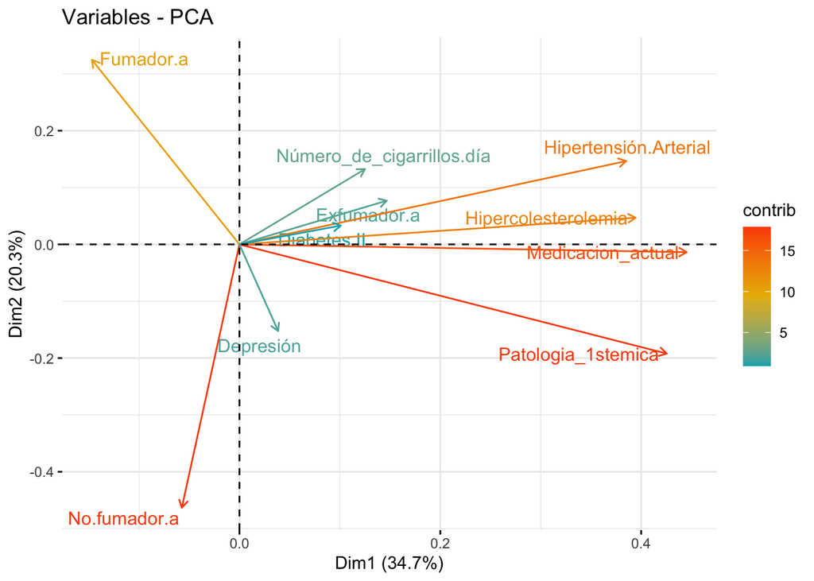

```r
plot_var_contrib_pca2
```